# Chilko growth exploration

November 20, 2020

## Chilko data summary

DFO StAD data on Chilko juvenile and adult sockeye (Figure 1):

- Smolt abundance at migration
- Smolt length at migration
- Smolt age at migration
- Smolt migration timing (daily totals) - this may exist at finer resolution too
- Fry abundance, age, and size (sparse data)
- Total adult spawner abundance
- Effective female spawner abundance
- Male and female spawner length
- Fecundity
- Adult age (total and freshwater)
- Water level (continuous) and temperature (during programs)

Smolt length and age and fry length and age are currently stored in data formats that would require considerable work to bring into a useable format, especially for historical data.

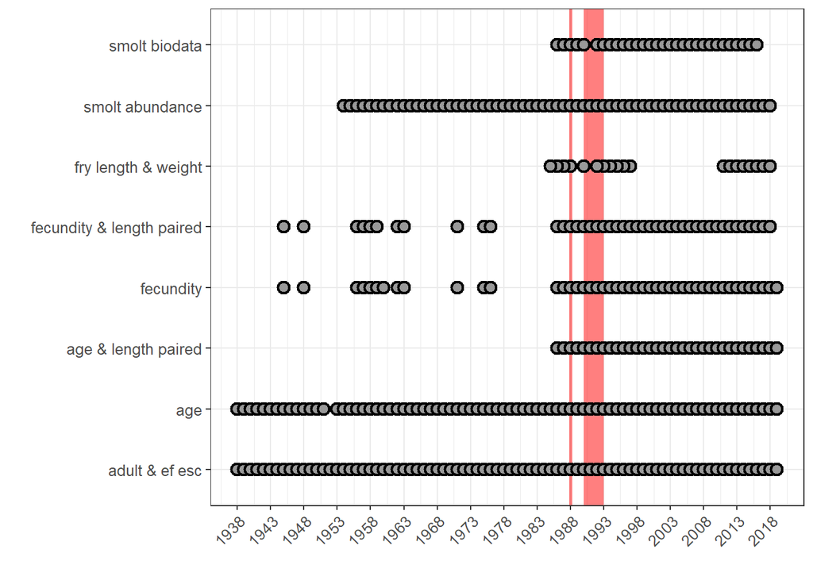

Figure 1. DFO Stock assessment time series for Chilko data types. No sex information was collected in conjunction with 'age' data in 1952 hence the gap. Lake fertilization years are coloured red (1988, 1990-1993).

Other types of data that may be held elsewhere:

- Smolt freshwater growth rate (otoliths, scales or recaptures?)
- Smolt weight
- Smolt fat score
- Smolt growth rate (otoliths, scales or recaptures?)
  - Smolt fork length in Lower Fraser/SoG
- Smolt survival during migration
  - Smolt abundance in Lower Fraser/SoG
- Smolt misc physiology - swim performance, hormones, respirometry, etc.
- Total growth rate over life (otoliths, scales) - PSC does not record to this level for adults but possible it could be obtained
- Adult fat score
- Adult misc physiology - swim performance, hormones, respirometry, etc.
- Fry abundance
- Lake productivity/food availability (especially during fertilization experimental years) - likely patchy at best
- Predator abundance (proxy or estimate of mortality rate)

Other data sources might be accessed through Environmental Watch Program, Hinch Lab, Mission Downstream (Tadey) or Strait of Georgia (Neville) programs.

### Other systems

Sparse fry data (Figure 2) and smolt data (below) exists for other systems if controls/comparisons are required:

- Cultus 1984, 1990-1991, 2000-2020
- Nautley 1999-2000, 2019
- South Thompson 2012-2013, 2016
- Historic (~1940-1950) Adams Lake, Bowron, Francois Lake, Horsefly, Lillooet Lake, Little River, Lower Shuswap, Portage Creek, Quesnel Lake, Seton Creek, South Thompson, Stuart Lake, Thompson

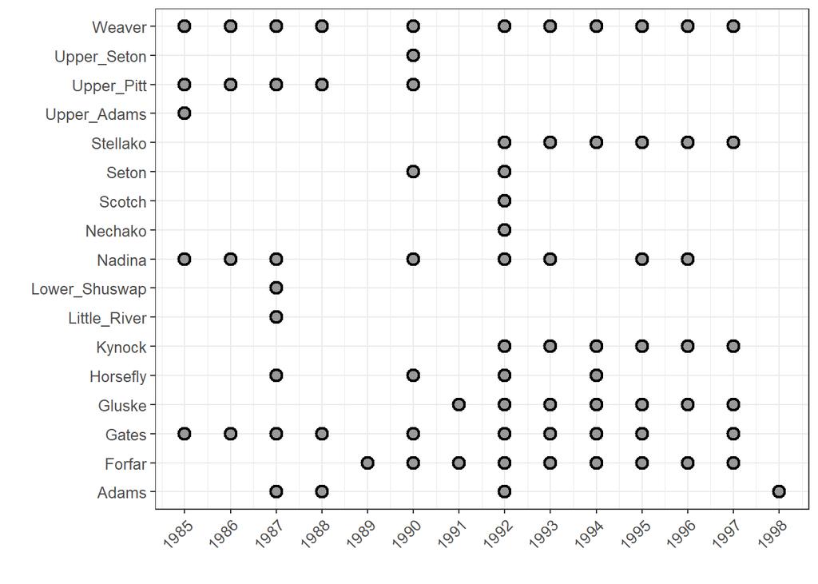

Figure 2. StA fry data excluding Chilko.

## Methods/overview

The majority of smolts leave Chilko Lake as age-1 (>81% from 1986-2019). Unless noted, all analysis from here-on is limited to age-1 smolts.

Given substantial variability in nightly smolt migration and the non-random method of obtaining smolt length samples, it is recommended that smolt lengths be weighted by nighly abundance (S. Decker). With the exception of a small number of data points, Figure 3 shows minimal difference between weighted and unweighted average smolt fork lengths each year.

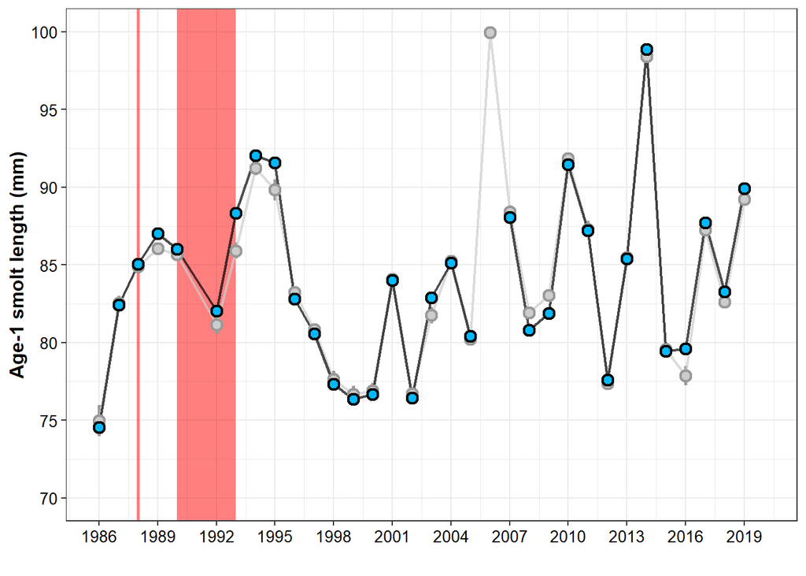

*Figure 3. Age-1 Chilko smolt fork lenghts, unweighted (light gray), and weighted-by-abundace (blue). Red shaded areas indicate years of lake fertilization. Error bars indicate one standard error and are given only for unweighted data. Note 2015 is included for comparison but due to high water an RST was used in place of the fence, which may result in size-selective bias. Following 2014 a 3-day smoothing window was also applied to daily weighted and unweighted length calculations.*

In the most recent 5 years (fence not operated in 2015 and 2020) there is a significant effect of 'day' on average daily age-1 smolt length, and occasionally on age-2 daily average length as daily smolth lengths oscillate (Code 1 and Figure 4). However, there is no overall temporal trend in smolth length throughout the migration period (*R^2* < 0.12 for all ages and years; Figure 4).

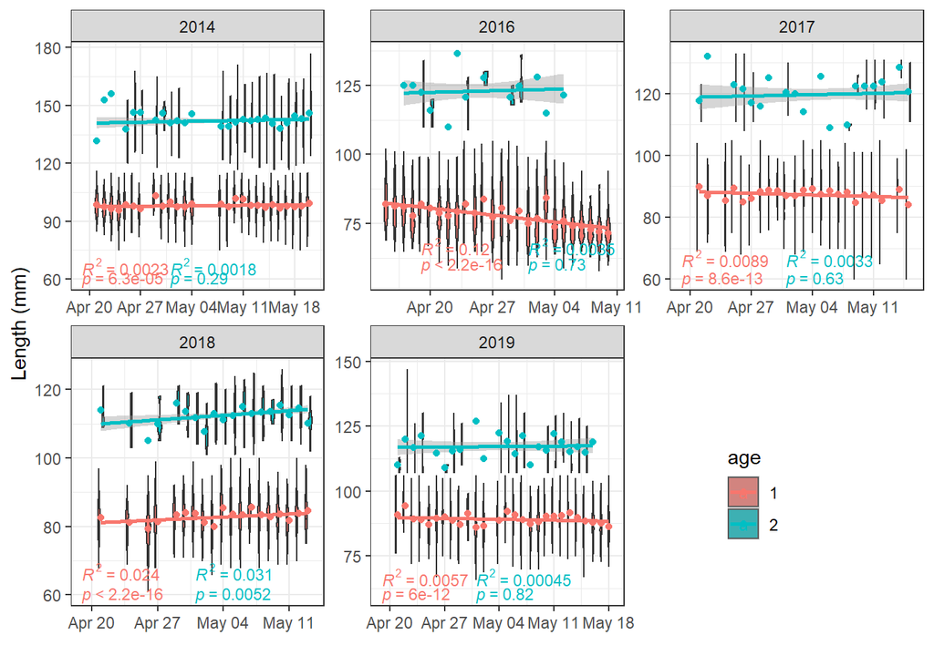

*Fig 4. Age-1 and -2 Chilko smolt length over time for most recent 5 years of data. Points indicate means. Violin widths indicate data density. Not different y-axis limits for each plot.*

*Code 1. Linear models examining the effect of 'day' on smolth length for each year and age.*

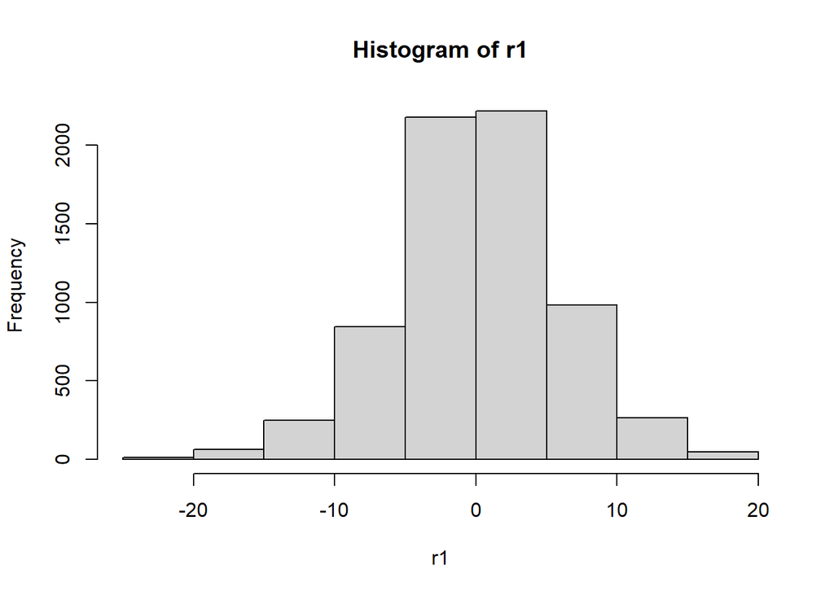

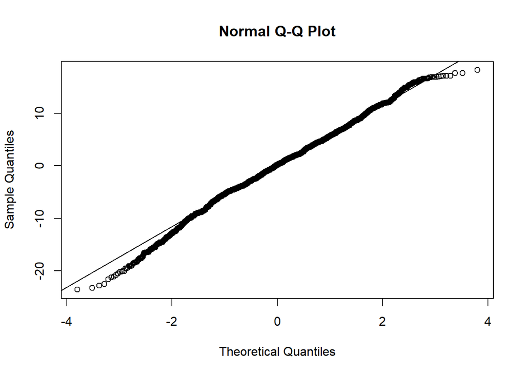

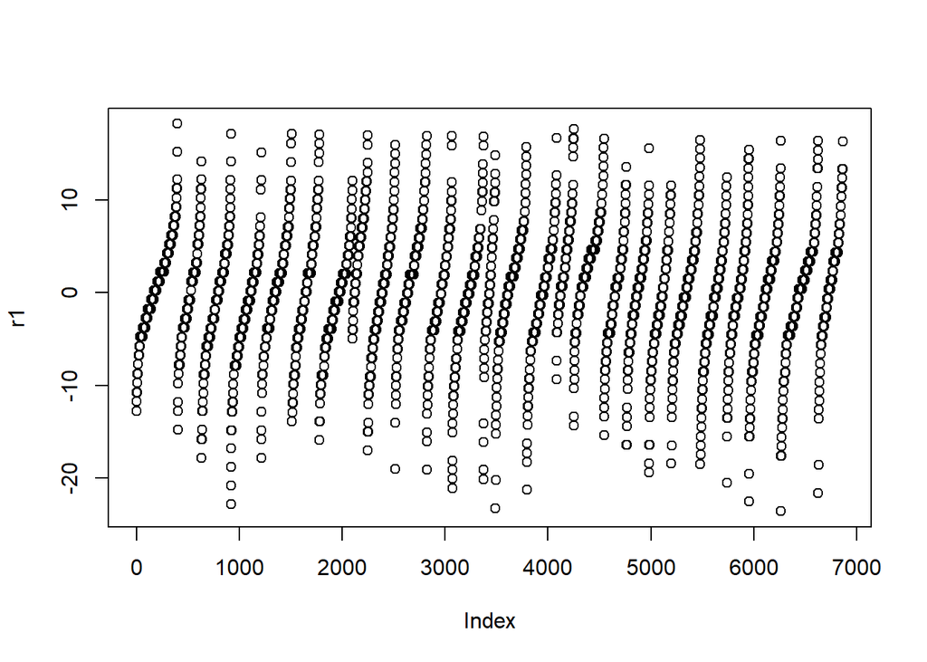

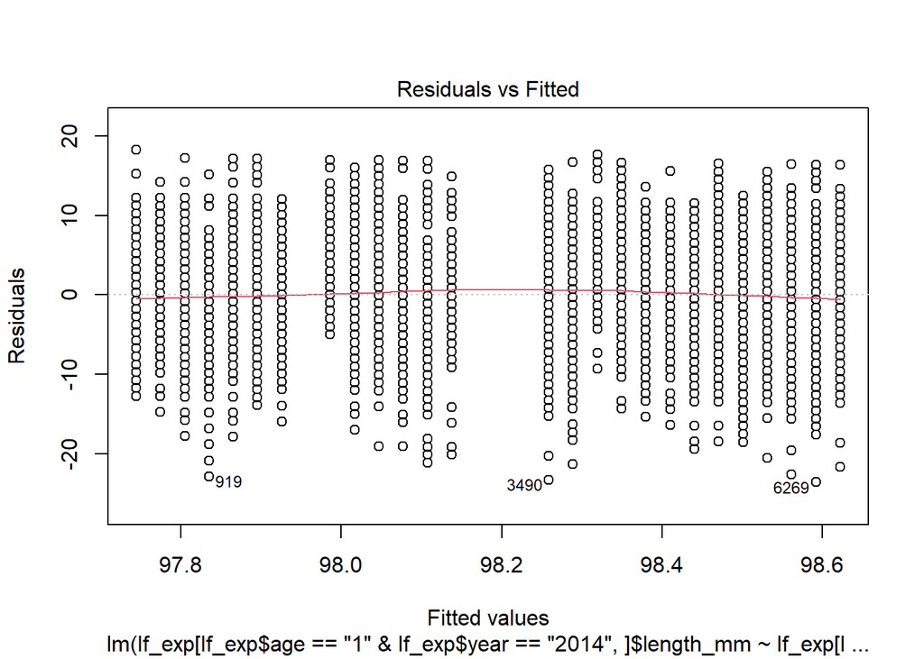

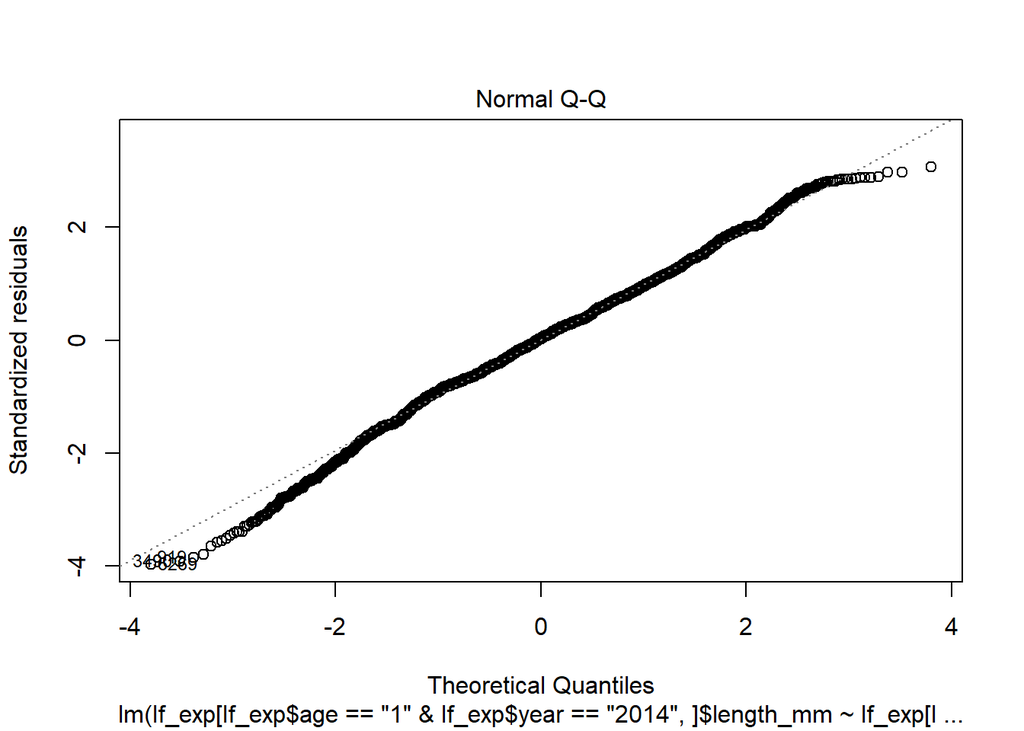

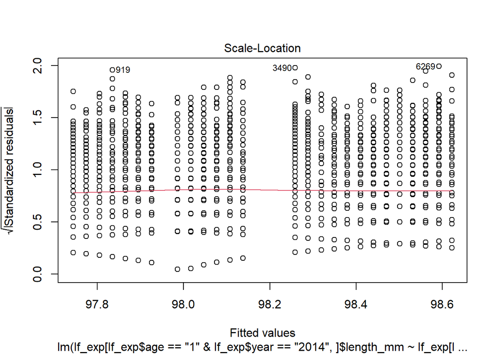

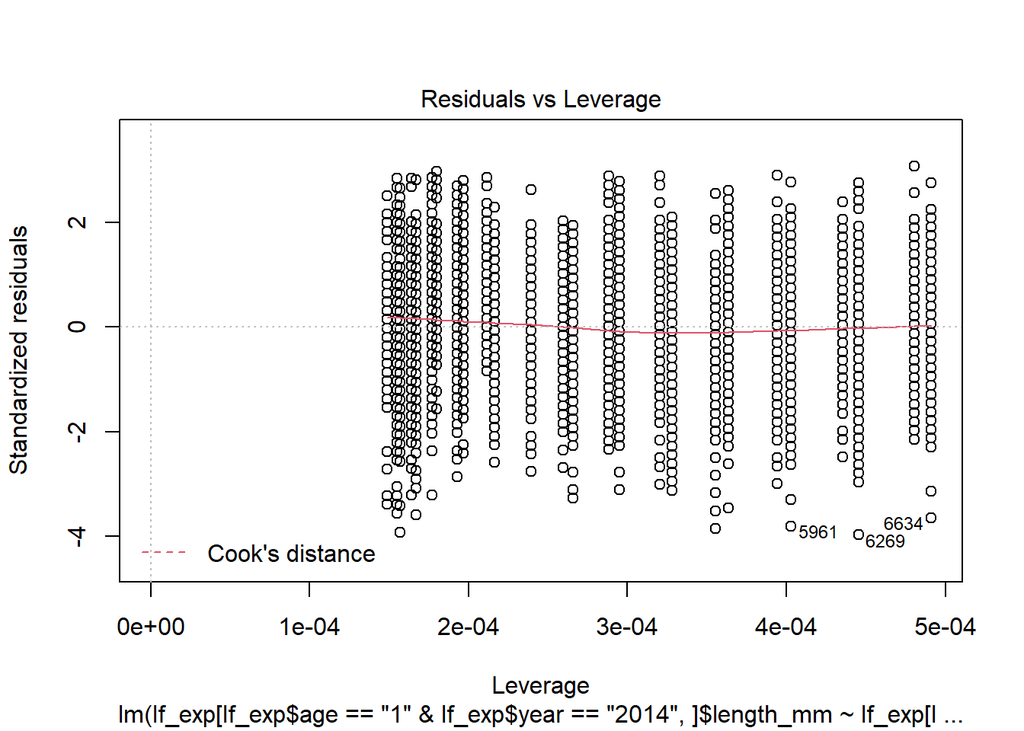

```
## # A tibble: 10 x 16
##    age    year data  fit   r.squared adj.r.squared sigma statistic   p.value
##    <fct> <dbl> <lis> <lis>     <dbl>         <dbl> <dbl>     <dbl>     <dbl>
##  1 1      2019 <tib~ <lm>   0.00566       0.00554   5.76   47.5    6.02e- 12
##  2 2      2019 <tib~ <lm>   0.000448     -0.00802   8.90    0.0528 8.19e-  1
##  3 1      2018 <tib~ <lm>   0.0235        0.0234    4.87  132.     3.58e- 30
##  4 2      2018 <tib~ <lm>   0.0313        0.0273    5.37    7.94   5.23e-  3
##  5 1      2017 <tib~ <lm>   0.00886       0.00869   5.75   51.4    8.57e- 13
##  6 2      2017 <tib~ <lm>   0.00332      -0.0105    7.77    0.240  6.26e-  1
##  7 1      2016 <tib~ <lm>   0.119         0.119     7.03 1287.     2.06e-264
##  8 2      2016 <tib~ <lm>   0.00353      -0.0249    7.55    0.124  7.27e-  1
##  9 1      2014 <tib~ <lm>   0.00233       0.00219   5.94   16.0    6.29e-  5
## 10 2      2014 <tib~ <lm>   0.00182       0.000191 10.8     1.12   2.91e-  1
## # ... with 7 more variables: df <dbl>, logLik <dbl>, AIC <dbl>, BIC <dbl>,
## #   deviance <dbl>, df.residual <int>, nobs <int>
```

## Size, abundance, and recruitment temporal trends

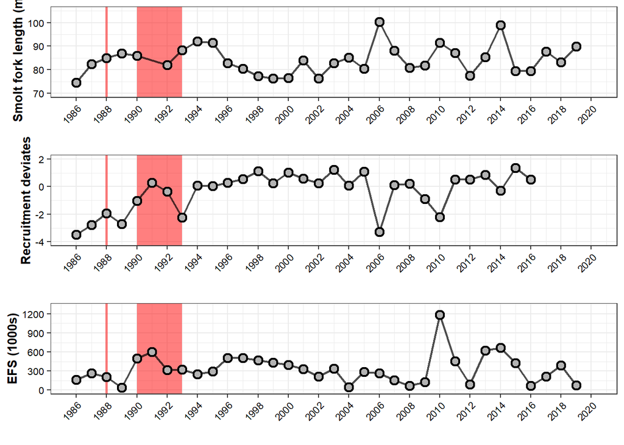

*Figure 6. a) Age-1 smolt fork length (weighted), b) Larkin model recruitment deviates, and c) effective female spawners over time.*

## Life history and recruitment

There is not a clear relationship between age-1 smolt size and the recruitment 2 years later. There is also not a clear relationship between the size of fry and age-1 smolts the following year (Figure 7).

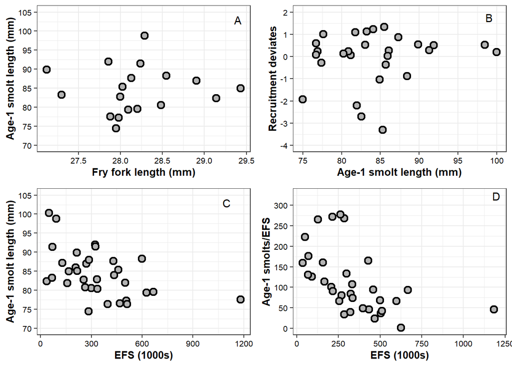

*Figure 7. Relationship between a) fry length and age-1 smolt length (weighted) the following year, b) age-1 smolt length (weighted) and recruitment (deviates) two years later, c) brood-year effective female spawners and resulting age-1 smolt length (weighted) two years later, and d) brood-year effective female spawners and resulting age-1 smolts per effective female spawner two years later.*